# Presentations in RMarkdown

Fall 2016

## The power of RMarkdown

http://rmarkdown.rstudio.com/

## R Presentation

- Default presentations in RStudio

[figure not shown]

https://support.rstudio.com/hc/en-us/sections/200130218-R-Presentations

## Formatting R presentations

### Beamer

- LaTeX-based document template for creating slides and presentations
- YAML setting: **`output: beamer_presentation`**
- YAML settings for **`theme`**, **`colortheme`**, **`fonttheme`**
- Markdown syntax can be mixed with LaTeX
- Presentation format: http://rmarkdown.rstudio.com/beamer_presentation_format.html
- Customizing Beamer slides: https://kbroman.wordpress.com/2013/10/07/better-looking-latexbeamer-slides

## Formatting R presentations

### ioslides

- Default format for RMarkdown presentations
- YAML setting: **`output: ioslides_presentation`**
- Markdown syntax can be mixed with HTML
- Presentation format: http://rmarkdown.rstudio.com/ioslides_presentation_format.html
- Example: https://github.com/mdozmorov/presentations/tree/master/reproducible_research/reproducible_research_2016-09-09

## Formatting R presentations

- **Slidy**: a HTML-based slideshow
  1. YAML setting: **output: slidy_presentation**
  2. Tutorial/example: https://www.w3.org/Talks/Tools/Slidy2/
- **reveal.js**: the HTML presentation framework, highly customizable
  1. YAML setting: **output: revealjs::revealjs_presentation**
  2. Example: http://lab.hakim.se/reveal-js/

## Slidify

- Customizable presentations in R Markdown. HTML-based. Can render presentations in any format.
- http://slidify.org/: 5 min video tutorial
- Example: Slidify: 'Reproducible HTML Slides from R Markdown', http://slidify.org/samples/intro/
- Themes: https://ramnathv.github.io/slidifyExamples/

## Tufte-style handouts

- Distinctive style of text with sidenotes
- `tufte` package implements rendering `tufte_handouts`, `tufte_book`, `tufte_html`
- Installed as a template
- Presentation format: http://rmarkdown.rstudio.com/tufte_handout_format.html

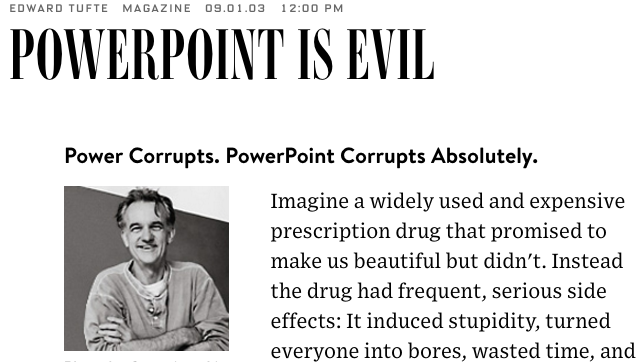

https://www.wired.com/2003/09/ppt2/

## Interactive reports

- Shiny - a web application framework for R, http://shiny.rstudio.com/
- Presentation format, http://rmarkdown.rstudio.com/authoring_shiny.html
- Generally used for exploratory data analysis

## Bookdown

- Authoring Books with R Markdown: https://github.com/rstudio/bookdown
- https://bookdown.org/: free books authored with bookdown
- Example: 'Bookdown: Authoring Books with R Markdown', https://bookdown.org/yihui/bookdown/

## Websites

### GitHub pages

- A simple way to make a website using Markdown and git, http://rmarkdown.rstudio.com/rmarkdown_websites.html
- GitHub pages hosting, https://pages.github.com/ - quick start on one page
- Example: 'Easy websites with GitHub Pages', http://kbroman.org/simple_site/

## Publishing articles

- LaTeX Journal Article Templates for R Markdown, https://github.com/rstudio/rticles

open access peer-reviewed scientific mega journal, https://peerj.com/

- Free preprint submission. Judges scientific/methodological rigor. Does not judge the results (may be null), interest or impact

https://github.com/PeerJ/paper-now

## Formulas in Markdown

- **MathJax** - formula rendering engine accepting LaTeX, MathML, or AsciiMath syntax.
- Inline formula - decorate with **`$..$`**
  - e.g. `"... when $x < y$ we have ..."`
  - becomes "… when \(x < y\) we have …"
- Self-standing equation - decorate with **`$$..$$`**
  - e.g. `$$\sum_{i=0}^n i^2 = \frac{(n^2+n)(2n+1)}{6}$$`
  - becomes \[\sum_{i=0}^n i^2 = \frac{(n^2+n)(2n+1)}{6}\]

https://en.wikibooks.org/wiki/LaTeX/Mathematics

http://meta.math.stackexchange.com/questions/5020/mathjax-basic-tutorial-and-quick-reference

## RPubs

- http://rpubs.com/: publishing R Markdown reports and presentation on the web
- Everything public
- Example: 'R Cookbook - Chapter 11 - Linear Regression and ANOVA', http://rpubs.com/escott8908/RC11

[figure not shown]